# Numerical Methods for PDEs (Spring 2017), Lab 8

Richard Southwell, Gustav Delius

# Non-linear heat equation

In this lab you will explore the backward difference method for the non-linear heat equation

$$\frac{\partial u}{\partial t} =\frac{\partial }{\partial x}\left(K(x,t,u)
\frac{\partial u}{\partial x}\right)+f(x,t,u), \quad 0<x< L, \quad t>0,$$
subject to the initial and boundary conditions
$$u(x, 0) = u_{0}(x), \qquad u(0,t)=0, \quad u(L,t)=0.$$

## Semi-implicit method

We will extend the function `backwardDifference()` from Lab 5 to allow $K$ and $f$ to be functions of $x, t$ and $u$. Initially we will use the method from eq.(2.106) in the lecture notes, which evaluates $K$ and $f$ at the $w$ from the previous time step in order to avoid having to solve a non-linear equation at each time step. Such a method is sometimes called “semi-implicit”.

```r
backwardDifference2 <- function(u0, K, f, L=1, N=30, T=1, M=30) {
    # set up space grid
    h <- L/N
    x <- h*(1:(N-1))
    xFull <- h*(0:N)

    # set up time grid
    tau <- T/M
    t <- tau*(0:M)

    gamma <- tau/h^2

    w <- matrix(0, N-1, M+1)  # Matrix to hold the solution
    w[ , 1] <- u0(x)  # Initial value
    # Loop over time steps
    for (j in 1:M) {
        Kv <- K(xFull, t[j], c(0, w[, j], 0))
        chi <- (Kv[1:N] + Kv[2:(N+1)])/2
        a <- 1 + gamma*(chi[2:N]+chi[1:(N-1)])
        b <- -gamma*chi[1:(N-1)]
        w[, j+1] <- doublesweep(b[1:(N-1)], c(b[2:(N-1)],0), -a,
                                w[, j]+tau*f(x, t[j], w[, j]), 0, 0)
    }

    # Return a list consisting of time grid, x grid and solution
    return(list(x=x, t=t, w=w))
}
```

We will use the implementation of the doublesweep method from Lab 5:

```r
doublesweep <- function(A, B, C, F, a, b) {
    # Solves the equation
    # A[i]*v[i-1] - C[i]*v[i] + B[i]*v[i+1] = F[i]
    # for v[i], i = 1,...,N-1, with boundary conditions
    # v[0]=a and v[N]=b

    # Check the lengths of the vectors
    N <- length(C) + 1
    if ((length(B) != N-1) || (length(A) != N-1) || (length(F) != N-1)) {
        stop("The lengths of the vector arguments need to be equal")
    }

    alpha <- rep(0, N)
    beta <- rep(0, N)
    beta[1] <- a

    #sweep up to get alphas and betas
    for (i in 1:(N-1)) {
        alpha[i+1] <- B[i] / (C[i]-alpha[i]*A[i])
        beta[i+1] <- (beta[i]*A[i] - F[i]) / (C[i] - alpha[i]*A[i])
    }

    v <- rep(0, N-1 )
    v[N-1] <- alpha[N]*b + beta[N]

    #sweep down to find v's
    for (i in (N-1):2) {
        v[i-1] <- alpha[i]*v[i] + beta[i]
    }

    return(v)
}
```

Let us look at the solution of the equation
$$\frac{\partial u}{\partial t} =\frac{\partial }{\partial x}\left(\frac12 u^2
\frac{\partial u}{\partial x}\right)-u, \quad 0<x< L, \quad t>0,$$
with initial condition
$$u(x,0) = \max(0, 1-10|x-0.5|)$$

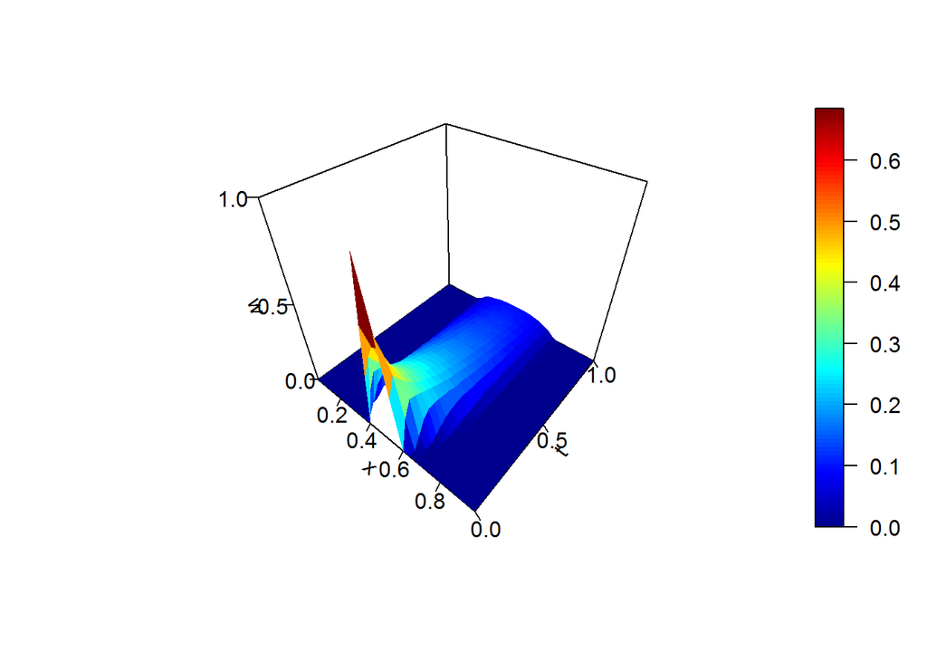

```r
sol <- backwardDifference2(u0=function(x) pmax(0, 1-10*abs(x-0.5)),
                           K=function(x, t, u) u^2/2,
                           f=function(x, t, u) -u)
library("plot3Drgl")
persp3D(sol$x, sol$t, sol$w,
        xlab="x", ylab="t", zlab="w",
        ticktype="detailed", nticks=4)
```

### Exercise 1

Solve the equation
$$\frac{\partial u}{\partial t} =\frac{\partial }{\partial x}\left(x\,t\,u^2
\frac{\partial u}{\partial x}\right)+8x\sin(8\pi xt), \quad 0<x< 1, \quad 0<t<1,$$
with the same initial condition as above.

## Method of successive approximations

We now add another loop to our function `backwardDifference2()` that implements the method of successive approximations, see eq.(2.107) in the lecture notes.

We introduce two extra arguments to the function: `max_iterations` is the maximum number of iterations for the successive approximation method and `tolerance` is the amount of error that is acceptable. So the iterations are stopped as soon as the result varies by less than `tolerance`.

```r
backwardDifference2 <- function(u0=function(x) pmax(0,1-10*abs(x-0.5)),
                                K=function(x, t, u) u^2/2,
                                f=function(x, t, u) -u^2,
                                L=1, N=30, T=1, M=30,
                                max_iteration=20, tolerance=0.000001) {
    # set up space grid
    h <- L/N
    x <- h*(1:(N-1))
    xFull <- h*(0:N)

    # set up time grid
    tau <- T/M
    t <- tau*(0:M)

    gamma <- tau/h^2

    w <- matrix(0, N-1, M+1)  # Matrix to hold the solution
    iterations <- rep(0, M)  # to hold number of iterations needed at each step
    precision <- rep(0, M)  # to hold precision achieved

    w[ , 1] <- u0(x)  # Initial value
    # Loop over time steps
    for (j in 1:M) {
        wn <- w[, j]  # initial guess for w_{j+1}
        for (s in 1:max_iteration) {
            ws <- wn
            Kv <- K(xFull, t[j], c(0, ws, 0))
            chi <- (Kv[1:N] + Kv[2:(N+1)])/2
            a <- 1 + gamma*(chi[2:N]+chi[1:(N-1)])
            b <- -gamma*chi[1:(N-1)]
            # update guess for w_{j+1}
            wn <- doublesweep(b[1:(N-1)], c(b[2:(N-1)],0), -a,
                              w[, j]+tau*f(x, t[j], ws), 0, 0)
            # break if tolerance limit is reached
            if (max(abs(wn-ws)) < tolerance) {
                break
            }
        }
        iterations[j] <- s
        precision[j] <- max(abs(wn-ws))
        w[, j+1] <- wn
    }

    # Return a list consisting of time grid, x grid and solution
    return(list(x=x, t=t, w=w, iterations=iterations, precision=precision))
}
```

Note that we have also added two more items to the returned list: `iterations` lists the number of iterations actually performed at each time step and `precision` is the amount by which the approximation changed during the final iteration at each time step.

Let us use this modified function on our simple example

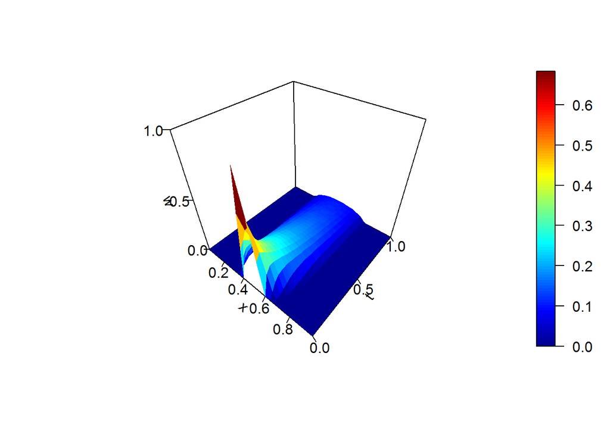

```r
sol <- backwardDifference2(u0=function(x) pmax(0, 1-10*abs(x-0.5)),
                           K=function(x, t, u) u^2/2,
                           f=function(x, t, u) -u)

persp3D(sol$x, sol$t, sol$w,
        xlab="x", ylab="t", zlab="w",
        ticktype="detailed", nticks=4)
```

Let us look at how many iterations are used in the method of successive approximations in order to reach the tolerance limit of 0.000001

```r
sol$iterations
```

```
 [1] 12 10  8  8  7  7  6  6  6  5  5  5  5  5  5  5  4  4  4  4  4  4  4
[24]  4  4  4  4  4  4  4
```

Not surprisingly we wee that more iterations are needed in the initial time steps during which the solution changes a lot between steps.

```r
sol$precision
```

```
 [1] 9.105796e-07 3.224462e-07 9.878271e-07 1.747697e-07 4.125659e-07
 [6] 1.892498e-07 5.665140e-07 2.392183e-07 1.798262e-07 9.310214e-07
[11] 6.389977e-07 4.108559e-07 2.472733e-07 1.412456e-07 1.177494e-07
[16] 8.878365e-08 8.743438e-07 7.638492e-07 6.710907e-07 5.930303e-07
[21] 5.270853e-07 4.711119e-07 4.233538e-07 3.823823e-07 3.470379e-07
[26] 3.163795e-07 2.896419e-07 2.662014e-07 2.455472e-07 2.272596e-07
```

If we had allowed only a single iteration the precision would have been poor:

```r
sol <- backwardDifference2(u0=function(x) pmax(0, 1-10*abs(x-0.5)),
                           K=function(x, t, u) u^2/2,
                           f=function(x, t, u) -u,
                           max_iteration = 1)
sol$precision
```

```
 [1] 0.454265171 0.109023810 0.085703189 0.039304261 0.034122898
 [6] 0.026747541 0.019298380 0.016471467 0.014367164 0.012740410
[11] 0.011444611 0.010387016 0.009506235 0.008760133 0.008118907
[16] 0.007560934 0.007070172 0.006634486 0.006244533 0.005893006
[21] 0.005574108 0.005283180 0.005016436 0.004770764 0.004543585
[26] 0.004332740 0.004136410 0.003953048 0.003781334 0.003620128
```

```r
sol <- backwardDifference2(u0=function(x) pmax(0, 1-10*abs(x-0.5)),
                           K=function(x, t, u) u^2/2,
                           f=function(x, t, u) -u,
                           max_iteration = 2)
sol$precision
```

```
 [1] 0.0549127439 0.0159807368 0.0107710162 0.0045668489 0.0033783290
 [6] 0.0022540563 0.0016565548 0.0013278137 0.0010888422 0.0009104263
[11] 0.0007740702 0.0006676461 0.0005830063 0.0005145563 0.0004583708
[16] 0.0004116383 0.0003723061 0.0003388485 0.0003101139 0.0002852202
[21] 0.0002634828 0.0002443641 0.0002274373 0.0002123599 0.0001988548
[26] 0.0001866955 0.0001756958 0.0001657011 0.0001565825 0.0001482314
```

### Exercise 2

How many iterations are required for the example from exercise 1 with a tolerance of $10^{-6}$? What precision is achieved with just 4 iterations?